# Breast_Cancer_Jaime_Ulayar

Jaime Ulayar Arroyo

2023-02-28

# Importar datos

Al abrir el archivo “Breast_Cancer_train.data” con el bloc de notas se ve que el delimitador de campos es el conjunto de caracteres “h_”. El archivo de información nos indica que no se incluyen los nombres de las columnas en el archivo.

```r
library(readr)
Breast_Cancer_train <- read_delim("Breast_Cancer_train.data",
                                  delim = "h_", escape_double = FALSE, col_names = FALSE,
                                  trim_ws = TRUE)
Breast_Cancer_test <- read_delim("Breast_Cancer_test.data",
    delim = "\\/", escape_double = FALSE,
    col_names = names(Breast_Cancer_train)[1:11],
    trim_ws = TRUE)
```

# Renombrar campos

Renombramos los campos manualmente de acuerdo a la información proporcionada en “breast-cancer.names”.

```r
names(Breast_Cancer_train) <- c("ID",
                                "Thick",
                                "Size",
                                "Shape",
                                "MargAdhe",
                                "SingSize",
                                "Nuclei",
                                "Chrom",
                                "Nucleoli",
                                "Mitoses",
                                "Group",
                                "Class")

names(Breast_Cancer_test) <- c("ID",
                                "Thick",
                                "Size",
                                "Shape",
                                "MargAdhe",
                                "SingSize",
                                "Nuclei",
                                "Chrom",
                                "Nucleoli",
                                "Mitoses",
                                "Group")
```

# Inspección, correción y visualización de variables

Recorremos en un bucle todas las columnas del dataframe e inspeccionamos que valores encontramos dentro de cada variable.

```r
for(i in 2:length(Breast_Cancer_train)){
  print(c(names(Breast_Cancer_train)[i],table(Breast_Cancer_train[[i]])))
}
```

```
##               1       2       3       4       5       6       7       8       9
## "Thick"   "118"    "40"    "90"    "58"   "107"    "29"    "16"    "38"     "9"
##      10      30     100
##    "52"     "1"     "1"
##             ?      1     10      2      3     30      4      5      6      7
## "Size"    "1"  "306"   "56"   "34"   "42"    "1"   "28"   "24"   "23"   "17"
##      8      9
##   "22"    "5"
##              -7       ?       1     1.0      10       2       3       4       5
## "Shape"     "1"     "1"   "280"     "1"    "44"    "43"    "47"    "33"    "30"
##       6       7       8      80       9
##    "25"    "24"    "22"     "1"     "7"
##                    -1          1          2          3          4          5
## "MargAdhe"        "1"      "326"       "43"       "48"       "26"       "18"
##          6          7          8          9         10        100
##       "18"       "12"       "21"        "3"       "42"        "1"
##                     1          2          3          4          5          6
## "SingSize"       "38"      "305"       "57"       "37"       "33"       "25"
##          7          8          9         10         60        100
##       "11"       "19"        "2"       "29"        "2"        "1"
##                 ?        1       10        2        3        4        5
## "Nuclei"     "15"    "320"    "105"     "24"     "20"     "17"     "27"
##        6        7        8        9
##      "1"      "5"     "18"      "7"
##               1       2       3       4       5       6       7       8       9
## "Chrom"   "127"   "126"   "130"    "32"    "27"     "9"    "60"    "21"    "10"
##      10      11
##    "16"     "1"
##                     ?          1         10          2        2.0          3
## "Nucleoli"        "1"      "355"       "48"       "25"        "1"       "37"
##          4          5          6          7          8          9
##       "15"       "16"       "18"       "11"       "20"       "12"
##                   1         2         3         4         5         6         7
## "Mitoses"     "471"      "23"      "27"       "9"       "5"       "2"       "6"
##         8        10
##       "6"      "10"
##               1       2       3       4       5       6       7       8
## "Group"   "286"    "59"    "24"    "17"    "37"    "40"    "23"    "73"
##               ?       2      20       3       4      44
## "Class"     "1"   "361"     "1"     "4"   "188"     "4"
```

```r
for(i in 2:length(Breast_Cancer_test)){
  print(c(names(Breast_Cancer_test)[i],table(Breast_Cancer_test[[i]])))
}
```

```
##               1       2       3       4       5       6       7       8       9
## "Thick"    "27"    "10"    "17"    "22"    "23"     "5"     "7"     "7"     "5"
##      10      80
##    "16"     "1"
##             ?      1     10      2      3     30      4      5      6      7
## "Size"    "1"   "77"   "11"   "11"    "7"    "1"   "12"    "6"    "4"    "2"
##      8      9
##    "7"    "1"
##               ?       1      10       2       3       4       5       6       7
## "Shape"     "1"    "72"    "14"    "15"     "9"    "11"     "4"     "5"     "4"
##       8
##     "5"
##                     1          2          3          4          5          6
## "MargAdhe"       "80"       "15"       "10"        "7"        "5"        "4"
##          7          8          9         10
##        "1"        "4"        "2"       "12"
##                     ?          1         10          2          3          4
## "SingSize"        "1"        "9"        "1"       "80"       "15"       "11"
##          5          6          7          8
##        "6"       "14"        "1"        "2"
##                 ?        1       10        2        3        4        5
## "Nuclei"      "1"     "82"     "27"      "6"      "8"      "2"      "3"
##        6        7        8        9
##      "3"      "3"      "3"      "2"
##               ?       1      10       2       3       4       5       6       7
## "Chrom"     "1"    "24"     "4"    "40"    "35"     "7"     "7"     "1"    "13"
##       8       9
##     "7"     "1"
##                     1          2          3          4          5          6
## "Nucleoli"       "88"        "9"        "7"        "3"        "3"        "4"
##          7          8          9         10
##        "5"        "4"        "4"       "13"
##                   1         2         3         4         5         6         7
## "Mitoses"     "108"      "12"       "6"       "3"       "1"       "1"       "3"
##         8        10
##       "2"       "4"
##               1       2       3       5       6       7       8      60
## "Group"    "81"    "11"     "7"    "11"     "8"     "8"    "13"     "1"
```

La variable “Thick” es una variable numérica discreta (1-10). Sin embargo presenta dos valores que no entran en el rango de posibilidades (30 y 100). Lo más razonable es pensar que se ha incluido un 0 más a estos dos registros por accidente o por comas decimales. Se quita el último cero de ambos. En la dataset test hay un 80, que pasará a un 8.

```r
Breast_Cancer_train$Thick[Breast_Cancer_train$Thick > 10] <- Breast_Cancer_train$Thick[Breast_Cancer_train$Thick > 10]/10
table(Breast_Cancer_train$Thick)
```

```
##
##   1   2   3   4   5   6   7   8   9  10
## 118  40  91  58 107  29  16  38   9  53
```

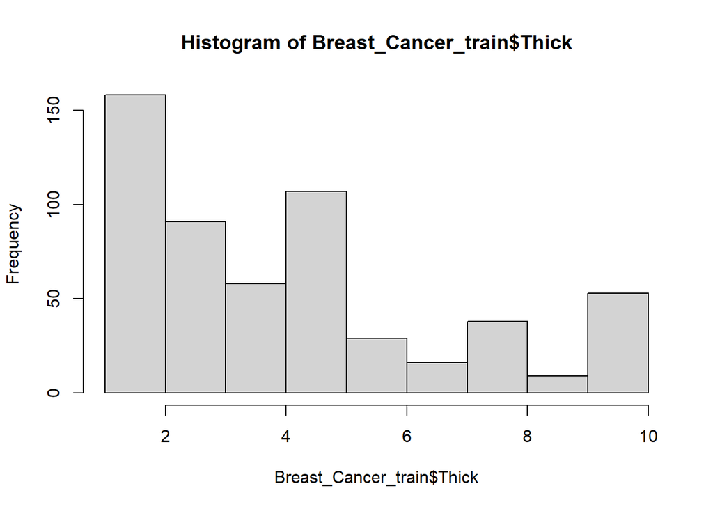

```r
hist(Breast_Cancer_train$Thick, breaks = 10)
```

```r
Breast_Cancer_test$Thick[Breast_Cancer_test$Thick > 10] <- Breast_Cancer_test$Thick[Breast_Cancer_test$Thick > 10]/10
```

La variable “Size” es una variable numérica discreta (1-10). Sin embargo presenta un valor “?” y otro valor de 30. El archivo informativo menciona que los datos perdidos se marcan con un “?” por lo que el primero se sustituye por un NA y el otro se procede de la misma forma que con la variable “Thick”. Una vez corregido estos datos se guarda la variable como numérica ya que al contener “?” se detectó como caracter.

```r
Breast_Cancer_train$Size[Breast_Cancer_train$Size == "?"] <- NA
Breast_Cancer_train$Size[Breast_Cancer_train$Size == 30] <- 3
Breast_Cancer_train$Size <- as.numeric(Breast_Cancer_train$Size)
meanSize <- mean(Breast_Cancer_train$Size,na.rm = TRUE)
Breast_Cancer_train$Size[is.na(Breast_Cancer_train$Size)] <- meanSize
table(Breast_Cancer_train$Size)
```

```
##
##                1                2                3 3.17741935483871
##              306               34               43                1
##                4                5                6                7
##               28               24               23               17
##                8                9               10
##               22                5               56
```

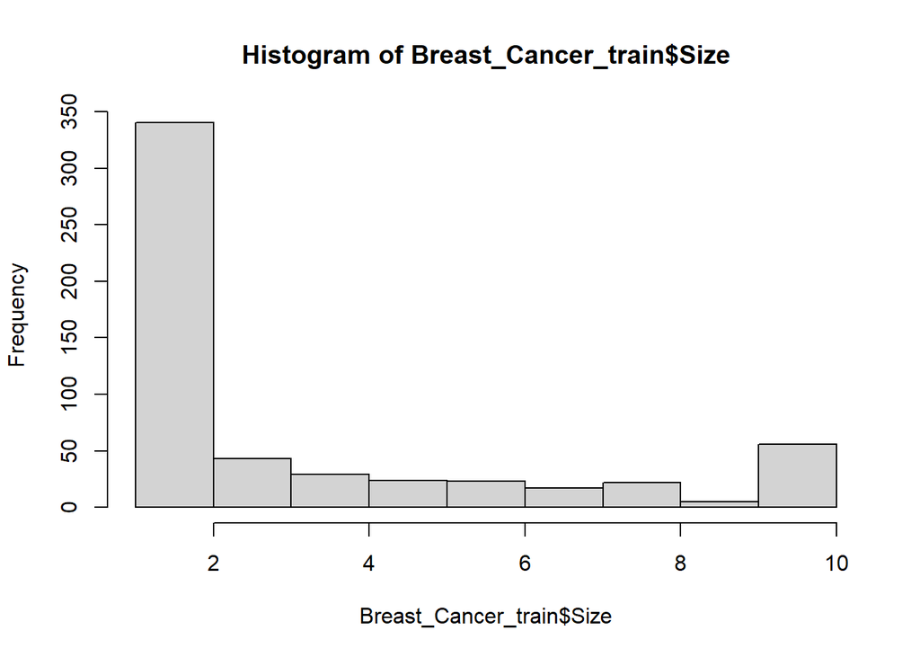

```r
hist(Breast_Cancer_train$Size, breaks = 10)
```

```r
Breast_Cancer_test$Size[Breast_Cancer_test$Size == "?"] <- NA
Breast_Cancer_test$Size[Breast_Cancer_test$Size == 30] <- 3
Breast_Cancer_test$Size[is.na(Breast_Cancer_test$Size)] <- meanSize
Breast_Cancer_test$Size <- as.numeric(Breast_Cancer_test$Size)
```

La variable “Shape” es una variable numérica discreta (1-10). Contiene un -7, un 1.0, un “?” y un 80. Lo más razonable es pensar que se añadió un “-” por accidente delante del siete. El número decimal se redondea como un entero. Los otros datos son análogos a ejemplos anteriores. Al contener “?” se leyó como caracter. Se pasa a variable numerica.

```r
Breast_Cancer_train$Shape[Breast_Cancer_train$Shape == "?"] <- NA
Breast_Cancer_train$Shape[Breast_Cancer_train$Shape == "-7"] <- "7"
Breast_Cancer_train$Shape[Breast_Cancer_train$Shape == "1.0"] <- "1"
Breast_Cancer_train$Shape[Breast_Cancer_train$Shape == "80"] <- "8"
Breast_Cancer_train$Shape <- as.numeric(Breast_Cancer_train$Shape)
meanShape <- mean(Breast_Cancer_train$Shape,na.rm = TRUE)
Breast_Cancer_train$Shape[is.na(Breast_Cancer_train$Shape)] <- meanShape
table(Breast_Cancer_train$Shape)
```

```
##
##                1                2                3 3.22939068100358
##              281               43               47                1
##                4                5                6                7
##               33               30               25               25
##                8                9               10
##               23                7               44
```

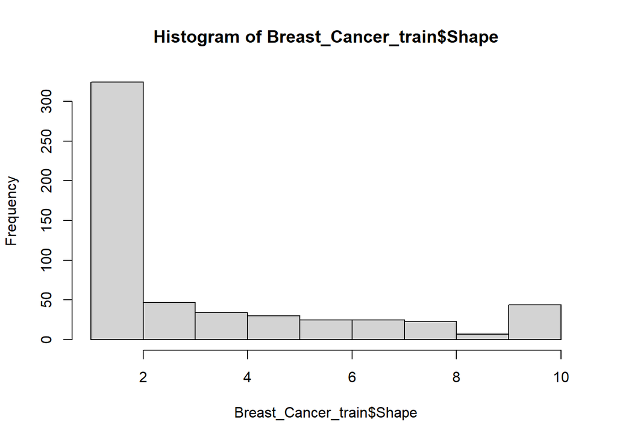

```r
hist(Breast_Cancer_train$Shape, breaks = 10)
```

```r
Breast_Cancer_test$Shape[Breast_Cancer_test$Shape == "?"] <- NA
Breast_Cancer_test$Shape <- as.numeric(Breast_Cancer_test$Shape)
Breast_Cancer_test$Shape[is.na(Breast_Cancer_test$Shape)] <- meanShape
```

La variable “MargAdhe” es una variable numérica discreta (1-10). Contiene un -1 y un 100. Se ignora el negativo y se quita un 0 al 100.

```r
Breast_Cancer_train$MargAdhe[Breast_Cancer_train$MargAdhe == -1] <- 1
Breast_Cancer_train$MargAdhe[Breast_Cancer_train$MargAdhe == 100] <- 10
table(Breast_Cancer_train$MargAdhe)
```

```
##
##   1   2   3   4   5   6   7   8   9  10
## 327  43  48  26  18  18  12  21   3  43
```

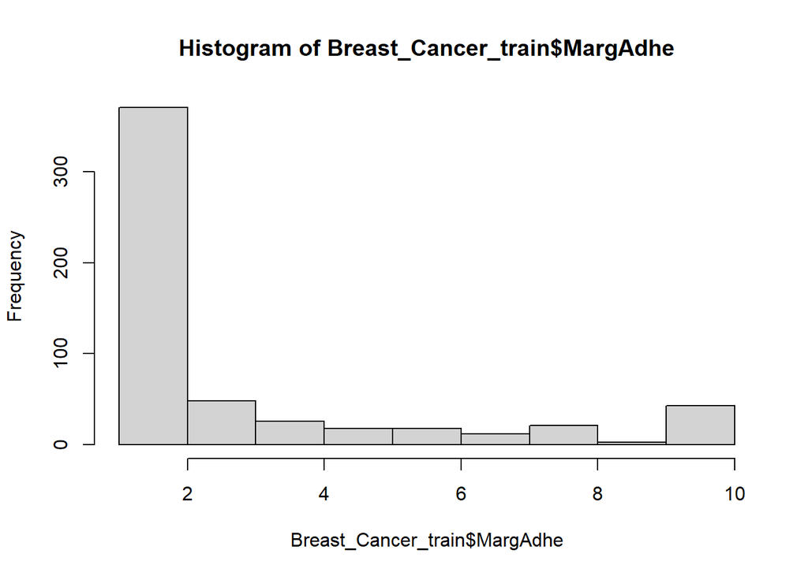

```r
hist(Breast_Cancer_train$MargAdhe, breaks = 10)
```

La variable “SingSize” es una variable numérica discreta (1-10). Contiene un 100 y dos 60. Se ignoran las ultimos ceros.

```r
Breast_Cancer_train$SingSize[Breast_Cancer_train$SingSize > 10] <- Breast_Cancer_train$SingSize[Breast_Cancer_train$SingSize > 10]/10
meanSingSize <- mean(Breast_Cancer_train$SingSize)
table(Breast_Cancer_train$SingSize)
```

```
##
##   1   2   3   4   5   6   7   8   9  10
##  38 305  57  37  33  27  11  19   2  30
```

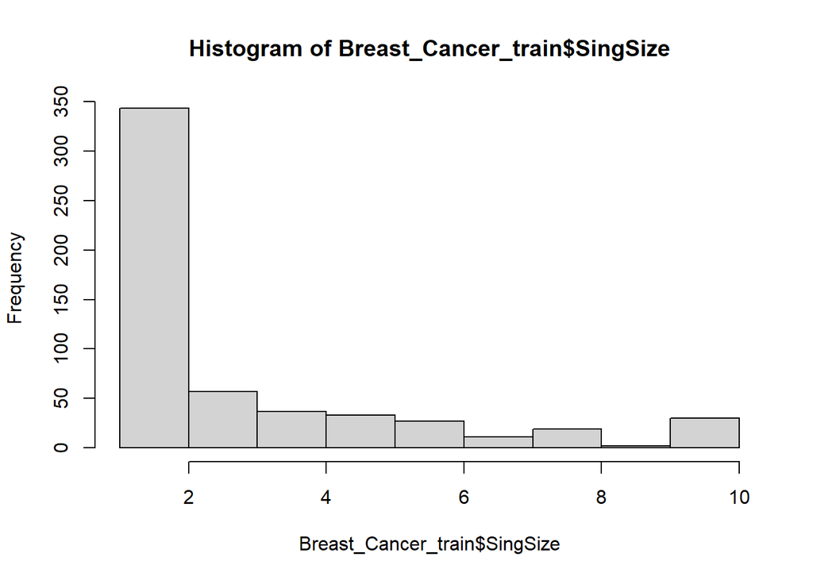

```r
hist(Breast_Cancer_train$SingSize, breaks = 10)
```

```r
Breast_Cancer_test$SingSize[Breast_Cancer_test$SingSize == "?"] <- NA
Breast_Cancer_test$SingSize <- as.numeric(Breast_Cancer_test$SingSize)
Breast_Cancer_test$SingSize[is.na(Breast_Cancer_test$SingSize)] <- meanSingSize
```

La variable “Nuclei” es una variable numérica discreta (1-10). Contiene varios “?”. Se guarda como una variable numérica.

```r
Breast_Cancer_train$Nuclei[Breast_Cancer_train$Nuclei == "?"] <- NA
Breast_Cancer_train$Nuclei <- as.numeric(Breast_Cancer_train$Nuclei)
meanNuclei <- mean(Breast_Cancer_train$Nuclei,na.rm = TRUE)
Breast_Cancer_train$Nuclei[is.na(Breast_Cancer_train$Nuclei)] <- meanNuclei
table(Breast_Cancer_train$Nuclei)
```

```
##
##                1                2                3 3.54595588235294
##              320               24               20               15
##                4                5                6                7
##               17               27                1                5
##                8                9               10
##               18                7              105
```

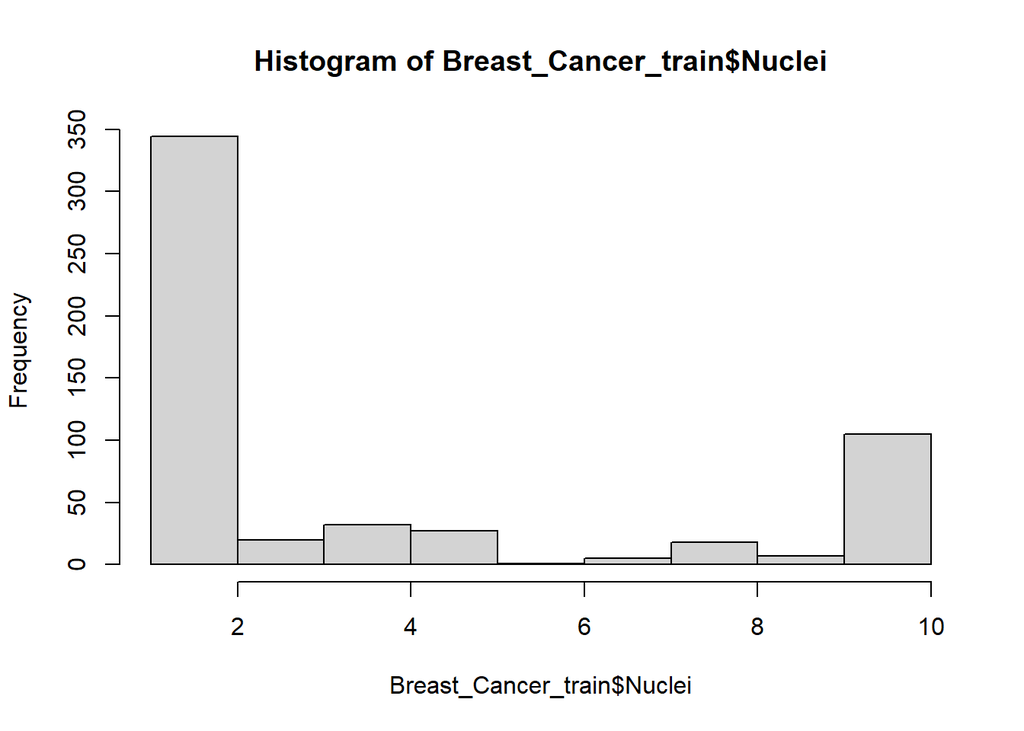

```r
hist(Breast_Cancer_train$Nuclei, breaks = 10)
```

```r
Breast_Cancer_test$Nuclei[Breast_Cancer_test$Nuclei == "?"] <- NA
Breast_Cancer_test$Nuclei <- as.numeric(Breast_Cancer_test$Nuclei)
Breast_Cancer_test$Nuclei[is.na(Breast_Cancer_test$Nuclei)] <- meanNuclei
```

La variable “Chrom” es una variable numérica discreta (1-10). Contiene un 11. Lo más razonable es que se incluyeran dos veces 1 a la hora de digitalizar los datos. Se cambiará a un 1.

```r
Breast_Cancer_train$Chrom[Breast_Cancer_train$Chrom == 11] <- 1
meanChrom <- mean(Breast_Cancer_train$Chrom)
table(Breast_Cancer_train$Chrom)
```

```
##
##   1   2   3   4   5   6   7   8   9  10
## 128 126 130  32  27   9  60  21  10  16
```

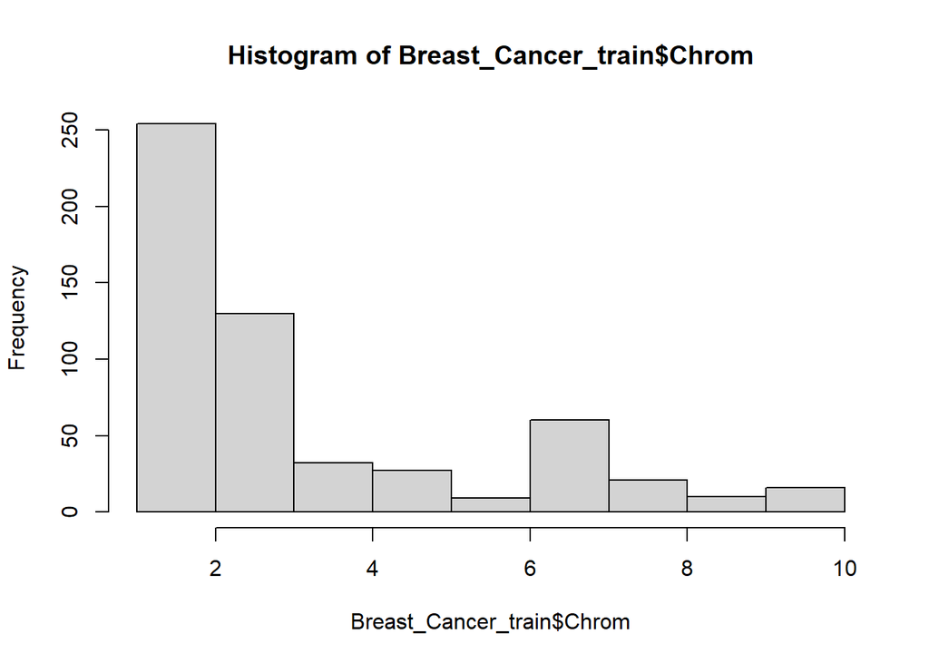

```r
hist(Breast_Cancer_train$Chrom, breaks = 10)
```

```r
Breast_Cancer_test$Chrom[Breast_Cancer_test$Chrom == "?"] <- NA
Breast_Cancer_test$Chrom <- as.numeric(Breast_Cancer_test$Chrom)
Breast_Cancer_test$Chrom[is.na(Breast_Cancer_test$Chrom)] <- meanChrom
```

La variable “Nucleoli” es una variable numérica discreta (1-10). Contiene un “?” y un 2.0. Se guarda como variable numerica.

```r
Breast_Cancer_train$Nucleoli[Breast_Cancer_train$Nucleoli == "?"] <- NA
Breast_Cancer_train$Nucleoli[Breast_Cancer_train$Nucleoli == "2.0"] <- 2
Breast_Cancer_train$Nucleoli <- as.numeric(Breast_Cancer_train$Nucleoli)
meanNucleoli <- mean(Breast_Cancer_train$Nucleoli,na.rm = TRUE)
Breast_Cancer_train$Nucleoli[is.na(Breast_Cancer_train$Nucleoli)] <- meanNucleoli
table(Breast_Cancer_train$Nucleoli)
```

```
##
##                1                2 2.85125448028674                3
##              355               26                1               37
##                4                5                6                7
##               15               16               18               11
##                8                9               10
##               20               12               48
```

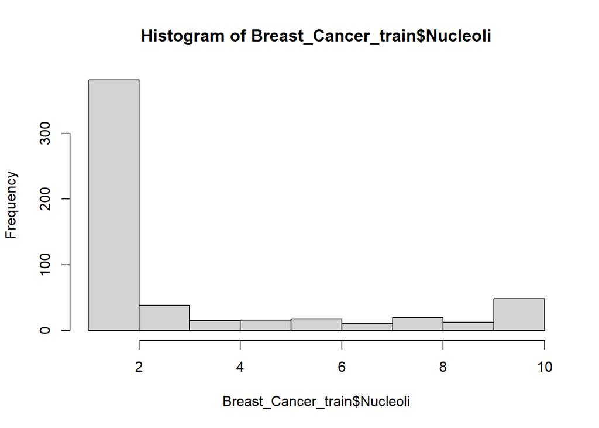

```r
hist(Breast_Cancer_train$Nucleoli, breaks = 10)
```

La variable “Mitoses” es una variable numérica discreta (1-10). No contiene valores fuera de lo esperado.

```r
table(Breast_Cancer_train$Mitoses)
```

```
##
##   1   2   3   4   5   6   7   8  10
## 471  23  27   9   5   2   6   6  10
```

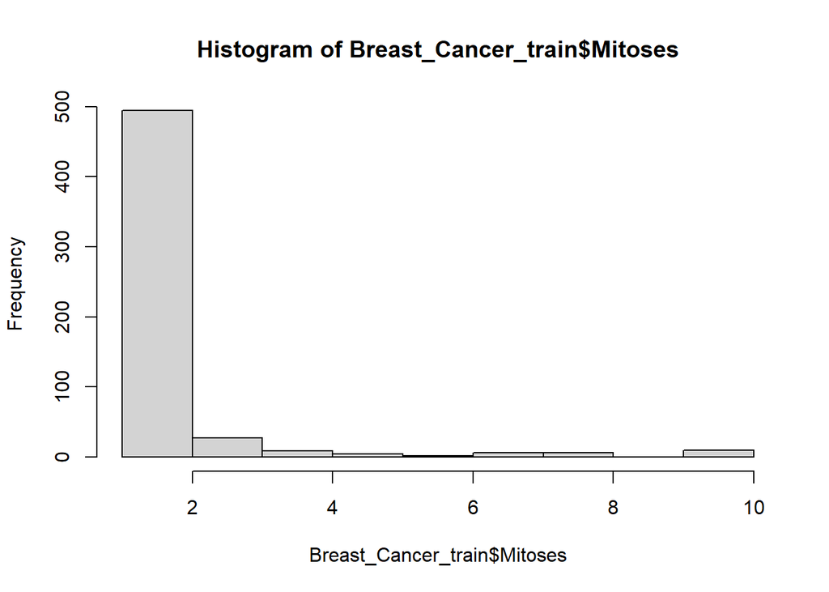

```r
hist(Breast_Cancer_train$Mitoses, breaks = 10)
```

La variable “Group” es un factor, pese a que se ha detectado como una variable numérica al ser sus niveles numéricos. Se convierte a factor.

```r
Breast_Cancer_train$Group <- as.factor(Breast_Cancer_train$Group)
table(Breast_Cancer_train$Group)
```

```
##
##   1   2   3   4   5   6   7   8
## 286  59  24  17  37  40  23  73
```

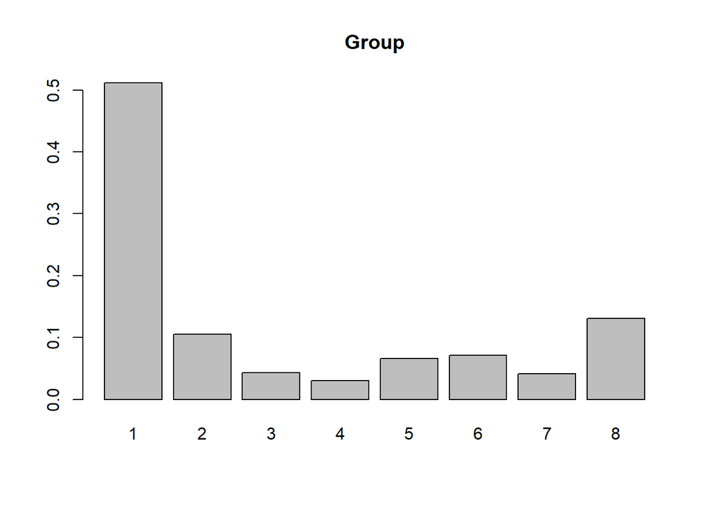

```r
barplot(prop.table(table(Breast_Cancer_train$Group)), main = "Group")
```

```r
Breast_Cancer_test$Group[Breast_Cancer_test$Group > 10] <- Breast_Cancer_test$Group[Breast_Cancer_test$Group > 10]/10
Breast_Cancer_test$Group <- as.factor(Breast_Cancer_test$Group)
```

La variable “Class”, la variable respuesta en este caso, es también un factor con solo dos niveles: “Benigno” y “Maligno”, para los valores 2 y 4 respectivamente. Contiene un “?”, algunos 3, un 20 y cuatro 44. Puesto que no hay razones sólidas para considerar los 3 como “Benigno” o “Maligno” se considerarán como NA. Los demás se gestionan análogamente a ejemplos anteriores.

```r
Breast_Cancer_train$Class[Breast_Cancer_train$Class == "3"] <- NA
Breast_Cancer_train$Class[Breast_Cancer_train$Class == "?"] <- NA
Breast_Cancer_train$Class[Breast_Cancer_train$Class == "44"] <- 4
Breast_Cancer_train$Class[Breast_Cancer_train$Class == "20"] <- 2
Breast_Cancer_train$Class <- as.factor(Breast_Cancer_train$Class)
levels(Breast_Cancer_train$Class) <- c("Benigno", "Maligno")
table(Breast_Cancer_train$Class)
```

```
##
## Benigno Maligno
##     362     192
```

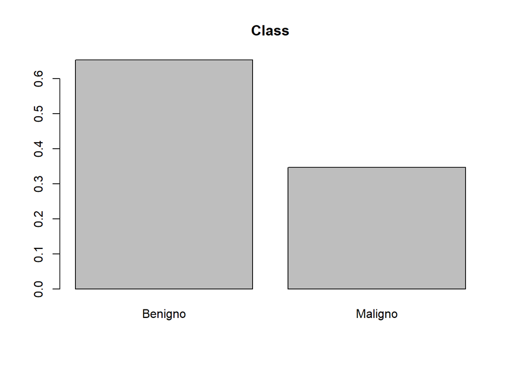

```r
barplot(prop.table(table(Breast_Cancer_train$Class)), main = "Class")
```

# Centralización y normalización

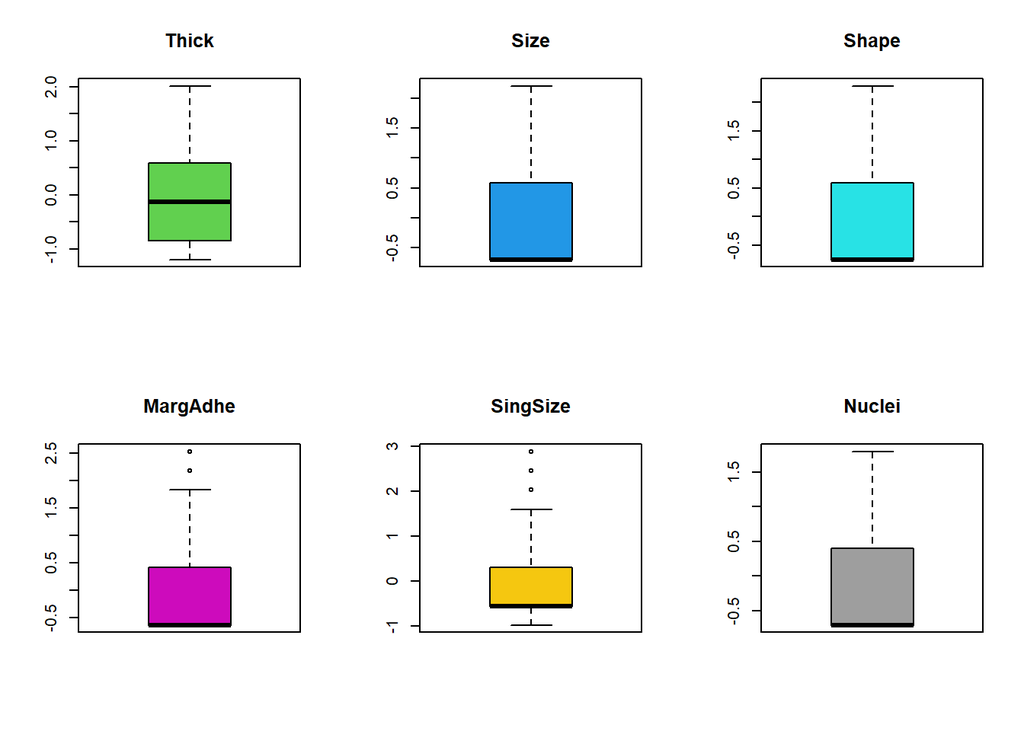

```r
centralizar_normalizar = function(train, test){
  centrada_train = train - mean(train, na.rm = TRUE)
  centrada_test = test - mean(train, na.rm = TRUE)
  normalizada_train = centrada_train/sd(train, na.rm = TRUE)
  normalizada_test = centrada_test/sd(train, na.rm = TRUE)
  return (list(normalizada_train, normalizada_test))
}

for (i in 2:(length(Breast_Cancer_train)-2)){
  lista <- centralizar_normalizar(Breast_Cancer_train[[i]], Breast_Cancer_test[[i]])
  Breast_Cancer_train[,paste0(names(Breast_Cancer_train)[i])] <- lista[1]
  Breast_Cancer_test[,paste0(names(Breast_Cancer_test[i]))] <- lista[2]
}

par(mfrow = c(2,3))
for (i in 2:7){
  boxplot(Breast_Cancer_train[[i]], main = names(Breast_Cancer_train)[i], col = i + 1, xlab = "")
}
```

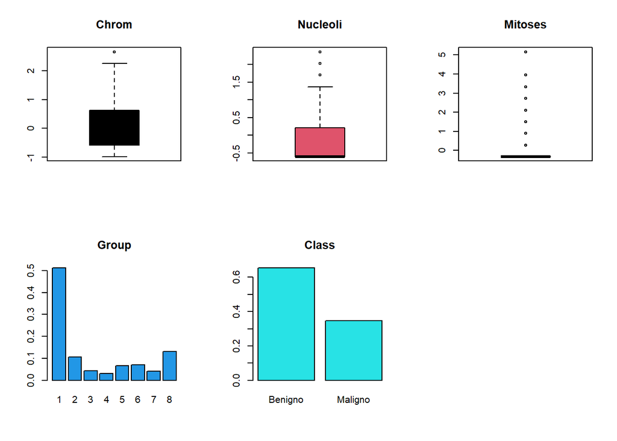

```r
par(mfrow = c(2,3))
for (i in 8:10){
  boxplot(Breast_Cancer_train[[i]], main = names(Breast_Cancer_train)[i], col = i + 1, xlab = "")
}

for (i in 11:12){
  barplot(prop.table(table(Breast_Cancer_train[[i]])), main = names(Breast_Cancer_train)[i], col = i + 1, xlab = "")
}
```

# Dummy variables

Convertimos el factor “Group” en 8 “dummy variables”, para poder discriminar que grupos son de verdad relevantes a la hora de realizar el modelo.

```r
library(dplyr)
Breast_Cancer_train$G1 <- ifelse(Breast_Cancer_train$Group == "1", 1, 0)
Breast_Cancer_train$G2 <- ifelse(Breast_Cancer_train$Group == "2", 1, 0)
Breast_Cancer_train$G3 <- ifelse(Breast_Cancer_train$Group == "3", 1, 0)
Breast_Cancer_train$G4 <- ifelse(Breast_Cancer_train$Group == "4", 1, 0)
Breast_Cancer_train$G5 <- ifelse(Breast_Cancer_train$Group == "5", 1, 0)
Breast_Cancer_train$G6 <- ifelse(Breast_Cancer_train$Group == "6", 1, 0)
Breast_Cancer_train$G7 <- ifelse(Breast_Cancer_train$Group == "7", 1, 0)
Breast_Cancer_train$G8 <- ifelse(Breast_Cancer_train$Group == "8", 1, 0)
Train_dataframe <- Breast_Cancer_train %>% select(-c(Group, ID))

Breast_Cancer_test$G1 <- ifelse(Breast_Cancer_test$Group == "1", 1, 0)
Breast_Cancer_test$G2 <- ifelse(Breast_Cancer_test$Group == "2", 1, 0)
Breast_Cancer_test$G3 <- ifelse(Breast_Cancer_test$Group == "3", 1, 0)
Breast_Cancer_test$G4 <- ifelse(Breast_Cancer_test$Group == "4", 1, 0)
Breast_Cancer_test$G5 <- ifelse(Breast_Cancer_test$Group == "5", 1, 0)
Breast_Cancer_test$G6 <- ifelse(Breast_Cancer_test$Group == "6", 1, 0)
Breast_Cancer_test$G7 <- ifelse(Breast_Cancer_test$Group == "7", 1, 0)
Breast_Cancer_test$G8 <- ifelse(Breast_Cancer_test$Group == "8", 1, 0)
Test_dataframe <- Breast_Cancer_test %>% select(-c(Group, ID))
```

# Modelos bivariantes

Analizamos una a una si hay alguna variable no significativa cuando es considerada individualmente frente a la variable respuesta “Class”.

```r
p_valores <- data.frame(matrix(NA, nrow = 1, ncol = length(Breast_Cancer_train)-2))

j = 1
for (i in Train_dataframe[1:18]){
  mod <- glm(Class ~ i, data = Train_dataframe, family = binomial(link = "logit"))
  valor <- coef(summary(mod))[2,4]
  p_valores[,j] <- valor
  j <- j+1
}
names(p_valores) <- names(Train_dataframe[1:18])
p_valores
```

```
##          Thick         Size        Shape     MargAdhe     SingSize       Nuclei
## 1 1.446078e-29 6.297697e-28 1.620664e-29 2.565518e-26 1.808508e-27 1.028577e-27
##          Chrom     Nucleoli      Mitoses     Class           G1          G2
## 1 1.409109e-25 5.933015e-25 6.060038e-11 0.9986666 1.853472e-09 0.003567212
##          G3        G4        G5         G6        G7           G8
## 1 0.5643673 0.1478286 0.3152069 0.09834097 0.1804117 0.0001784827
```

En este caso practicamente todas las variables son significativas a excepción de algunas dummy variables de la variable “Group”. Considerando un umbral menor que 0.2 para considerar si una variable es lo suficientemente significativa, los grupos 3 y 5 se pueden descartar.

# Modelo multivariante

Se propone un modelo multivariante inicial con todas las variables significativas halladas previamente.

```r
modFull <- glm(Class ~ Thick + Size + Shape + MargAdhe + SingSize + Nuclei + Chrom + Nucleoli + Mitoses + G1 + G2 + G4 + G6 + G7 + G8, data = Train_dataframe, family = binomial(link = "logit"))
summary(modFull)
```

```
##
## Call:
## glm(formula = Class ~ Thick + Size + Shape + MargAdhe + SingSize +
##     Nuclei + Chrom + Nucleoli + Mitoses + G1 + G2 + G4 + G6 +
##     G7 + G8, family = binomial(link = "logit"), data = Train_dataframe)
##
## Deviance Residuals:
##      Min        1Q    Median        3Q       Max
## -3.10143  -0.10329  -0.04677   0.02355   2.29376
##
## Coefficients:
##             Estimate Std. Error z value Pr(>|z|)
## (Intercept) -0.68448    0.99978  -0.685 0.493578
## Thick        1.71353    0.50013   3.426 0.000612 ***
## Size         0.17668    0.71694   0.246 0.805344
## Shape        0.86638    0.76180   1.137 0.255419
## MargAdhe     0.73399    0.38846   1.889 0.058826 .
## SingSize    -0.09513    0.39409  -0.241 0.809255
## Nuclei       1.30013    0.37109   3.504 0.000459 ***
## Chrom        1.05428    0.45891   2.297 0.021598 *
## Nucleoli     0.61642    0.39061   1.578 0.114540
## Mitoses      1.17465    0.91354   1.286 0.198509
## G1          -0.16032    1.05882  -0.151 0.879649
## G2          -3.38982    1.87514  -1.808 0.070643 .
## G4          -2.37197    4.88904  -0.485 0.627562
## G6          -1.58137    2.10982  -0.750 0.453540
## G7          -0.21106    1.97591  -0.107 0.914934
## G8          -1.29228    1.63017  -0.793 0.427937
## ---
## Signif. codes:  0 '***' 0.001 '**' 0.01 '*' 0.05 '.' 0.1 ' ' 1
##
## (Dispersion parameter for binomial family taken to be 1)
##
##     Null deviance: 714.990  on 553  degrees of freedom
## Residual deviance:  88.471  on 538  degrees of freedom
##   (5 observations deleted due to missingness)
## AIC: 120.47
##
## Number of Fisher Scoring iterations: 8
```

Con ayuda de la función “step” se van eliminando o incluyendo las distintas variables hasta que todas las incluidas sean consideradas significativas.

```r
modStep <- step(modFull, direction = "both",)
```

```
## Start:  AIC=120.47
## Class ~ Thick + Size + Shape + MargAdhe + SingSize + Nuclei +
##     Chrom + Nucleoli + Mitoses + G1 + G2 + G4 + G6 + G7 + G8
##
##            Df Deviance    AIC
## - G7        1   88.482 118.48
## - G1        1   88.493 118.49
## - SingSize  1   88.529 118.53
## - Size      1   88.533 118.53
## - G4        1   88.816 118.82
## - G6        1   89.093 119.09
## - G8        1   89.126 119.13
## - Shape     1   89.722 119.72
## <none>          88.471 120.47
## - Nucleoli  1   91.138 121.14
## - Mitoses   1   91.304 121.30
## - G2        1   91.765 121.77
## - MargAdhe  1   92.132 122.13
## - Chrom     1   94.247 124.25
## - Nuclei    1  102.894 132.89
## - Thick     1  104.038 134.04
##
## Step:  AIC=118.48
## Class ~ Thick + Size + Shape + MargAdhe + SingSize + Nuclei +
##     Chrom + Nucleoli + Mitoses + G1 + G2 + G4 + G6 + G8
##
##            Df Deviance    AIC
## - G1        1   88.495 116.50
## - SingSize  1   88.540 116.54
## - Size      1   88.542 116.54
## - G4        1   88.817 116.82
## - G6        1   89.103 117.10
## - G8        1   89.182 117.18
## - Shape     1   89.723 117.72
## <none>          88.482 118.48
## - Nucleoli  1   91.153 119.15
## - Mitoses   1   91.329 119.33
## - G2        1   92.092 120.09
## - MargAdhe  1   92.247 120.25
## + G7        1   88.471 120.47
```

[output cut: 120 more lines]

```
## - Nucleoli  1   93.087 109.09
## - Mitoses   1   93.402 109.40
## + G8        1   89.514 109.51
## - Shape     1   93.530 109.53
## + G6        1   89.780 109.78
## + G1        1   89.798 109.80
## + G4        1   90.035 110.03
## + SingSize  1   90.244 110.24
## + G7        1   90.281 110.28
## + Size      1   90.294 110.29
## - G2        1   94.495 110.50
## - MargAdhe  1   95.913 111.91
## - Chrom     1   96.257 112.26
## - Thick     1  107.034 123.03
## - Nuclei    1  107.495 123.50
```

```r
summary(modStep)
```

```
##
## Call:
## glm(formula = Class ~ Thick + Shape + MargAdhe + Nuclei + Chrom +
##     Nucleoli + Mitoses + G2, family = binomial(link = "logit"),
##     data = Train_dataframe)
##
## Deviance Residuals:
##      Min        1Q    Median        3Q       Max
## -3.07501  -0.11622  -0.05688   0.02226   2.35355
##
## Coefficients:
##             Estimate Std. Error z value Pr(>|z|)
## (Intercept)  -1.0289     0.3938  -2.613 0.008973 **
## Thick         1.7392     0.4905   3.546 0.000391 ***
## Shape         0.9906     0.5729   1.729 0.083807 .
## MargAdhe      0.7985     0.3432   2.327 0.019967 *
## Nuclei        1.3560     0.3563   3.806 0.000141 ***
## Chrom         0.9948     0.4283   2.323 0.020202 *
## Nucleoli      0.5851     0.3596   1.627 0.103707
## Mitoses       1.1134     0.8949   1.244 0.213440
## G2           -3.0760     1.5146  -2.031 0.042263 *
## ---
## Signif. codes:  0 '***' 0.001 '**' 0.01 '*' 0.05 '.' 0.1 ' ' 1
##
## (Dispersion parameter for binomial family taken to be 1)
##
##     Null deviance: 714.990  on 553  degrees of freedom
## Residual deviance:  90.294  on 545  degrees of freedom
##   (5 observations deleted due to missingness)
## AIC: 108.29
##
## Number of Fisher Scoring iterations: 8
```

Las variables “Mitoses” y “Nucleoli” aún no son especialmente significativas, por lo que se elimina “Mitoses”, al ser la menos significativa.

```r
modEnd <- glm(Class ~ Thick + Shape + MargAdhe + Nuclei + Chrom + Nucleoli + G2, data = Train_dataframe, family = binomial(link = "logit"))
summary(modEnd)
```

```
##
## Call:
## glm(formula = Class ~ Thick + Shape + MargAdhe + Nuclei + Chrom +
##     Nucleoli + G2, family = binomial(link = "logit"), data = Train_dataframe)
##
## Deviance Residuals:
##     Min       1Q   Median       3Q      Max
## -3.2224  -0.1151  -0.0518   0.0302   2.3594
##
## Coefficients:
##             Estimate Std. Error z value Pr(>|z|)
## (Intercept)  -1.2885     0.3228  -3.991 6.57e-05 ***
## Thick         1.9145     0.4578   4.182 2.89e-05 ***
## Shape         0.9599     0.5317   1.805 0.071020 .
## MargAdhe      0.7867     0.3320   2.369 0.017815 *
## Nuclei        1.3502     0.3598   3.753 0.000175 ***
## Chrom         1.1015     0.4091   2.693 0.007089 **
## Nucleoli      0.6778     0.3436   1.972 0.048555 *
## G2           -3.1874     1.4072  -2.265 0.023507 *
## ---
## Signif. codes:  0 '***' 0.001 '**' 0.01 '*' 0.05 '.' 0.1 ' ' 1
##
## (Dispersion parameter for binomial family taken to be 1)
##
##     Null deviance: 714.990  on 553  degrees of freedom
## Residual deviance:  93.402  on 546  degrees of freedom
##   (5 observations deleted due to missingness)
## AIC: 109.4
##
## Number of Fisher Scoring iterations: 8
```

# Tests de robustez del modelo

Antes de realizar la predicción vamos a comprobar lo bueno que resulta el modelo elegido con el propio dataset de entrenamiento. Para ello se define una función que extraiga las metricas de una predicción en relación con valor real de la variable respuesta.

```r
metrics <- function(observacion, prediccion, umbral){
vectorPred <- ifelse(prediccion > umbral, 1, 0)
vectorObs <- ifelse(observacion == "Benigno", 0, 1)
TP <- sum((vectorPred == vectorObs) & (vectorObs == 1), na.rm = TRUE)
TN <- sum((vectorPred == vectorObs) & (vectorObs == 0), na.rm = TRUE)
FP <- sum((vectorPred != vectorObs) & (vectorPred == 1), na.rm = TRUE)
FN <- sum((vectorPred != vectorObs) & (vectorPred == 0), na.rm = TRUE)
acc <- (TP+TN)/(TP+FP+FN+TN)
sen <- TP/(TP+FN)
FDR <- FP/(TP+FP)
pre <- TP/(TP+FP)
spe = TN/(TN+FN)
metricas <- data.frame(
  acc = acc,
  sen = sen,
  FDR = FDR,
  pre = pre,
  spe = spe
)
  return(metricas)
}

metricas <- data.frame()
```

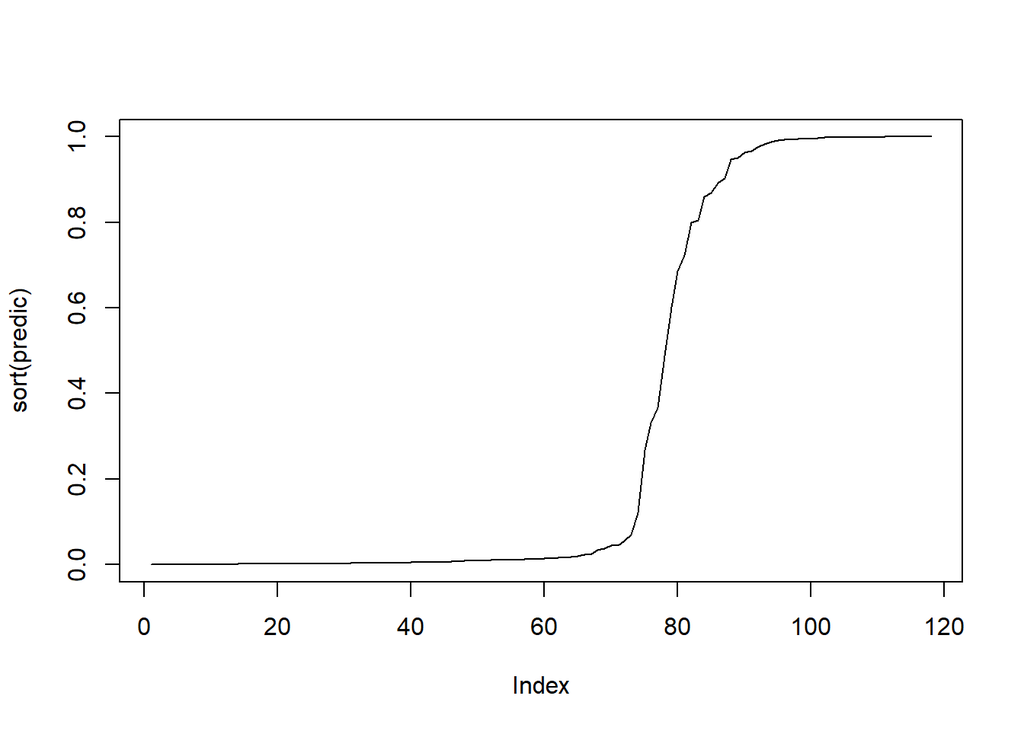

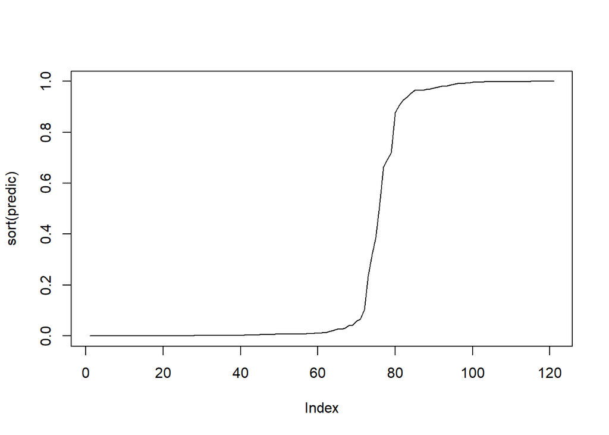

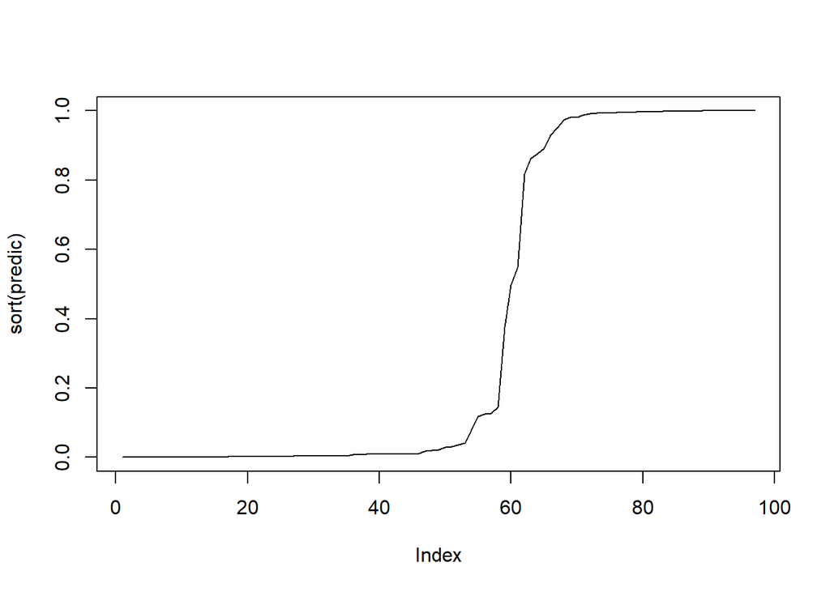

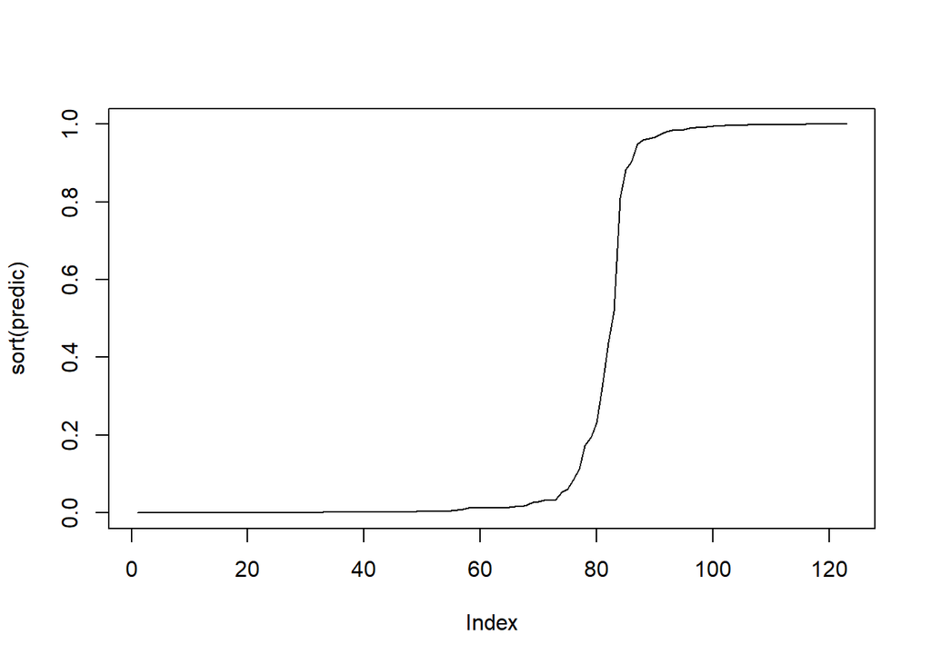

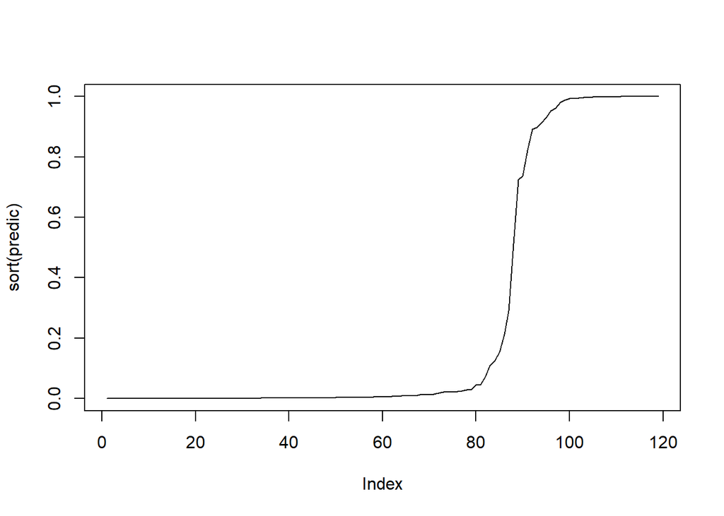

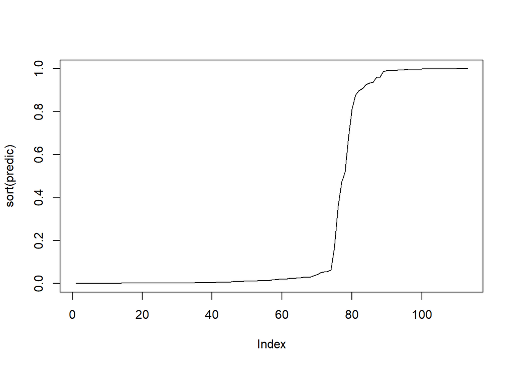

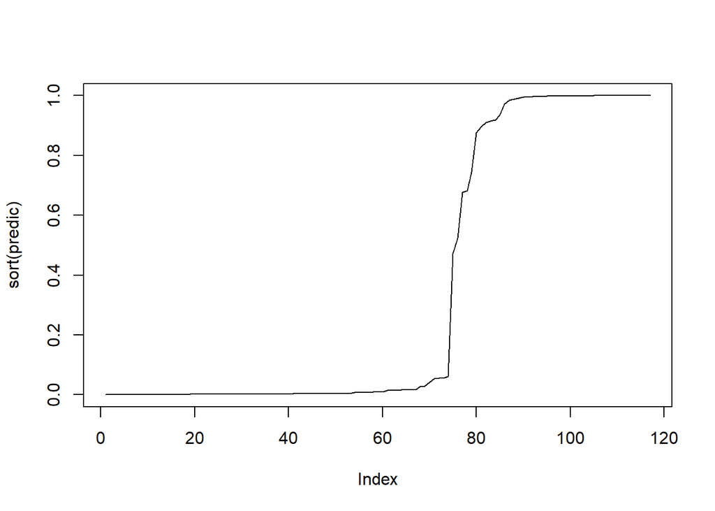

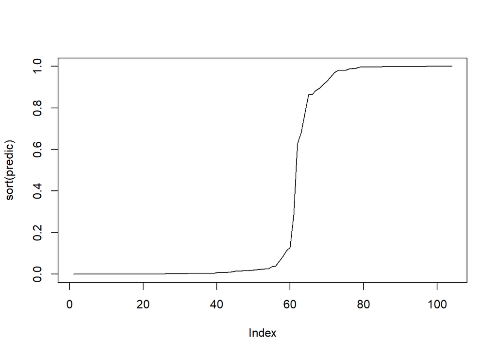

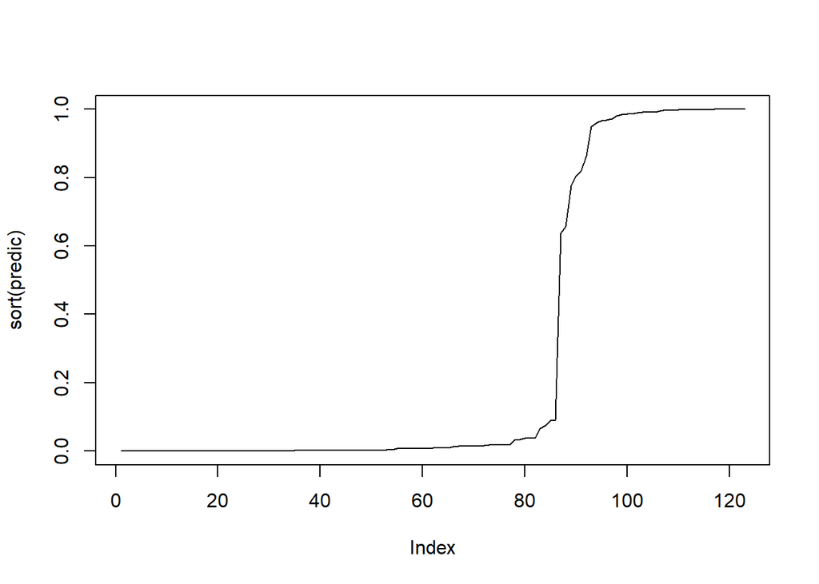

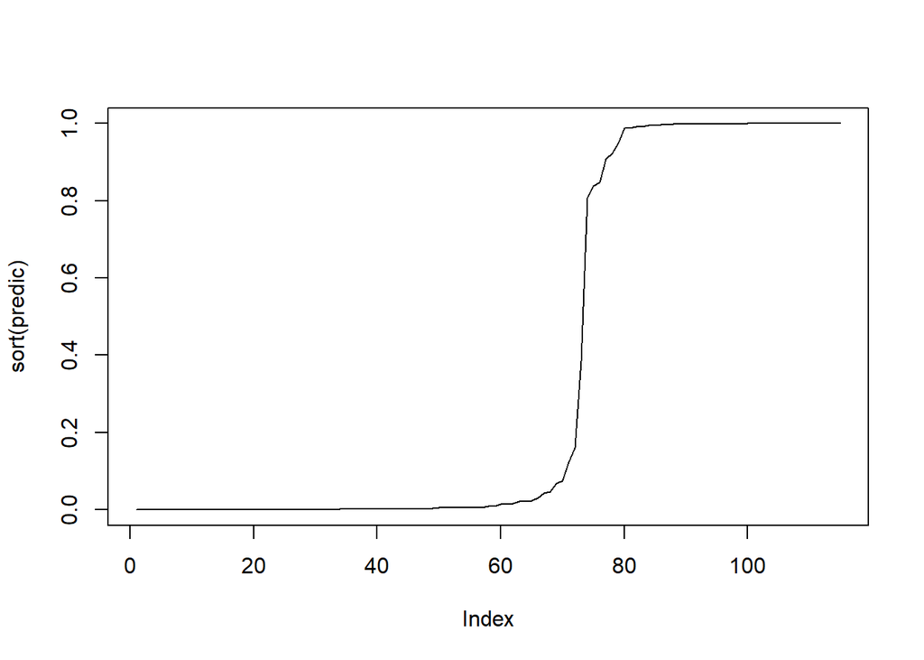

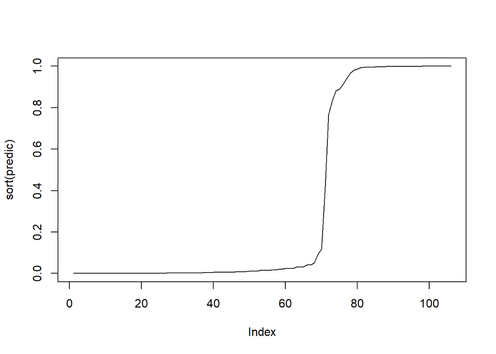

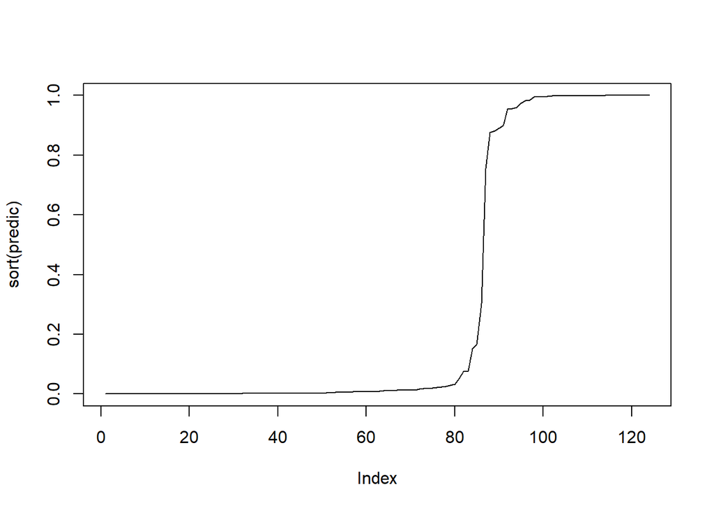

[8 more figures not shown]

```r
for (i in 1:20){
  sample <- sample(c(TRUE, FALSE), nrow(Train_dataframe), replace=TRUE, prob=c(0.80,0.20))
  train  <- Train_dataframe[sample, ]
  test   <- Train_dataframe[!sample, ]
  modTrain <- glm(Class ~ Thick + Shape + MargAdhe + Nuclei + Chrom + Nucleoli + G2, data = train, family = binomial(link = "logit"))
  predic <- predict(modTrain, type = "response", newdata = test)
  plot(sort(predic), type = "l")
  metricas <- rbind(metricas,metrics(test$Class,predic,0.6))
}
```

```r
colMeans(metricas)
```

```
##        acc        sen        FDR        pre        spe
## 0.95225081 0.93127057 0.07123932 0.92876068 0.96466794
```

# Predicción

Aplicamos el modelo entrenado sobre la base de datos de test para realizar la predicción.

```r
Test_prediccion <- predict(modEnd, type = "response", newdata = Test_dataframe)
Test_prediccion <- ifelse(Test_prediccion < 0.5, "Benigno", "Maligno")
```

Guardamos las predicciones en un csv de dos columnas. Una con el ID de cada registro y otra con la variable respuesta predicha por el modelo.

```r
Respuesta_csv <- data.frame(
  ID = Breast_Cancer_test$ID,
  Class = Test_prediccion
)

write.csv(Respuesta_csv, "Prediccion.csv", row.names=FALSE)
```